# 实验 3: 图像分类器

## 5 实验评估

### 5.1 对CNN层数进行减半

我们将五层的CNN更改为三层的CNN，观察训练集和验证集的准确率。

```python
def readfile(path,set):
    image_dir = sorted(os.listdir(path))
    x = np.zeros((len(image_dir),128,128,3),dtype = np.uint8) # 初始化，图片长宽为128，RGB三通道
    y = np.zeros((len(image_dir)),dtype = np.uint8) # 存储每张图片类别的向量
    for i ,file in enumerate(image_dir):
        img = cv2.imread(os.path.join(path, file)) # 读取图片
        x[i, :, :, :] = cv2.resize(img, (128,128)) # 将图片进行缩放，压缩为128*128*3
        if set == 'train' or set == 'validation':
            y[i] = int(file.split("_")[0]) # 数据前面是类别，后面是编号

    if set == 'train' or set == 'validation':
        return x, y
    else:
        return x

# 读取数据
data_dir = '/kaggle/input/dataset/food11'
train_x ,train_y = readfile(os.path.join(data_dir,"training"),"train")
val_x ,val_y = readfile(os.path.join(data_dir,"validation"),"validation")
test_x = readfile(os.path.join(data_dir,"test"),"test")

#导入数据
# 使用重写的 ImageDataSet 导入处理好的数据
train_set = ImageDataSet(train_x,train_y,train_transform)
val_set = ImageDataSet(val_x,val_y,test_valid_transform)
test_set = ImageDataSet(test_x,None,test_valid_transform)

#加载数据
batch_size = 128
train_loader = DataLoader(train_set,batch_size=batch_size,shuffle=True)
val_loader = DataLoader(val_set,batch_size=batch_size,shuffle=False)
test_loader = DataLoader(test_set,batch_size=batch_size,shuffle=False)

#将5层的神经网络更改为3层
class Image_Classifier(nn.Module):
    def __init__(self):
        super(Image_Classifier, self).__init__()

        # 修改后的三层卷积神经网络
        self.cnn = nn.Sequential(
            # 第一层卷积：输入3通道，输出64通道，卷积核大小3，步长1，填充1
            nn.Conv2d(3, 64, 3, 1, 1),  # 输入通道数 3 (RGB)，输出通道数 64，卷积核大小 3x3，步长 1，填充 1
            nn.BatchNorm2d(64),  # 进行批量归一化
            nn.ReLU(),  # 使用ReLU激活函数
            nn.MaxPool2d(2, 2, 0),  # 池化2x2，步长2，填充0

            # 第二层卷积：输入64通道，输出128通道，卷积核大小3，步长1，填充1
            nn.Conv2d(64, 128, 3, 1, 1),  # 输入通道64，输出通道128
            nn.BatchNorm2d(128),  # 批量归一化
            nn.ReLU(),  # ReLU激活函数
            nn.MaxPool2d(2, 2, 0),  # 池化2x2，步长2，填充0

            # 第三层卷积：输入128通道，输出256通道，卷积核大小3，步长1，填充1
            nn.Conv2d(128, 256, 3, 1, 1),  # 输入通道128，输出通道256
            nn.BatchNorm2d(256),  # 批量归一化
            nn.ReLU(),  # ReLU激活函数
            nn.MaxPool2d(2, 2, 0),  # 池化2x2，步长2，填充0
        )

        # 全连接层
        self.full_connect = nn.Sequential(
            # 修改后的全连接输入尺寸：256通道的特征图经过池化后变成 256x16x16
            nn.Linear(256 * 16 * 16, 1024),  # 将 256x16x16 的特征图展平为 1024 个特征
            nn.ReLU(),
            nn.Linear(1024, 512),  # 将 1024 个特征降到 512
            nn.ReLU(),
            nn.Linear(512, 11)  # 输出11个类别，适合分类任务
        )

    def forward(self, x):
        output = self.cnn(x)
        output = output.view(output.size()[0], -1)  # 展平特征图
        return self.full_connect(output)

model = Image_Classifier().cuda() #将Image_Classifier实例化，并加载到GPU上进行运算
loss = nn.CrossEntropyLoss() #分类模型，使用交叉熵损失
#创建一个Adam优化器，并将学习率设置为0.001，设置正则化参数为0.0001
optimizer = torch.optim.Adam(model.parameters(),lr=0.001,weight_decay=0.001)
epoch_num = 30 #小批量梯度下降

import time
from tqdm import trange
#开始训练！
for epoch in trange(epoch_num): #小批量梯度下降
    start_time = time.time()
    train_acc = 0.0
    train_loss = 0.0
    val_loss = 0.0
    val_acc = 0.0

    model.train() #切换至训练模式
    for i,(images,labels) in enumerate(train_loader):
        optimizer.zero_grad() #清空梯度
        train_pred = model(images.cuda()) #使用我们创建的模型进行训练
        batch_loss = loss(train_pred,labels.cuda()) #计算损失
        batch_loss.backward() #利用反向传播计算每一层参数的梯度
        optimizer.step() #更新梯度
        #与标签值对比，统计预测正确的个数
        train_acc += np.sum(np.argmax(train_pred.cpu().data.numpy(),axis=1)==labels.numpy())
        train_loss += batch_loss.item() #累计每个batch的损失

    train_acc = train_acc/train_set.__len__()
    train_loss = train_loss/train_set.__len__()

    model.eval() #切换至验证模式
    with torch.no_grad(): #在验证是不需要计算梯度
        for i ,(images,labels) in enumerate(val_loader):
            val_pred = model(images.cuda()) #使用我们创建的模型进行训练
            batch_loss = loss(val_pred,labels.cuda()) #计算损失

            #与标签值对比，统计预测正确的个数
            val_acc += np.sum(np.argmax(val_pred.cpu().data.numpy(),axis=1)==labels.numpy())
            val_loss += batch_loss.item() #累计每个batch的损失

        val_acc = val_acc/val_set.__len__()
        val_loss = val_loss/val_set.__len__()

        print('Train Acc: %3.6f Loss: %3.6f | Val Acc: %3.6f Loss: %3.6f' % (train_acc, train_loss, val_acc, val_loss))
```

```
Train Acc: 0.211028 Loss: 0.038837 | Val Acc: 0.237901 Loss: 0.016383
```

```
Train Acc: 0.329313 Loss: 0.014977 | Val Acc: 0.329446 Loss: 0.015317
```

```
Train Acc: 0.376951 Loss: 0.013976 | Val Acc: 0.370554 Loss: 0.013713
```

```
Train Acc: 0.425299 Loss: 0.012943 | Val Acc: 0.377843 Loss: 0.014333
```

```
Train Acc: 0.464829 Loss: 0.012072 | Val Acc: 0.420117 Loss: 0.013249
```

```
Train Acc: 0.503142 Loss: 0.011239 | Val Acc: 0.467930 Loss: 0.012298
```

```
Train Acc: 0.534665 Loss: 0.010477 | Val Acc: 0.344898 Loss: 0.015477
```

```
Train Acc: 0.550679 Loss: 0.009985 | Val Acc: 0.481050 Loss: 0.012065
```

```
Train Acc: 0.602270 Loss: 0.009001 | Val Acc: 0.351603 Loss: 0.016718
```

```
Train Acc: 0.625481 Loss: 0.008560 | Val Acc: 0.498542 Loss: 0.012010
```

```
Train Acc: 0.645854 Loss: 0.007948 | Val Acc: 0.445773 Loss: 0.013804
```

```
Train Acc: 0.687107 Loss: 0.007059 | Val Acc: 0.453936 Loss: 0.013332
```

```
Train Acc: 0.691770 Loss: 0.007061 | Val Acc: 0.406997 Loss: 0.016710
```

```
Train Acc: 0.710014 Loss: 0.006538 | Val Acc: 0.527988 Loss: 0.011916
```

```
Train Acc: 0.751976 Loss: 0.005568 | Val Acc: 0.256851 Loss: 0.025893
```

```
Train Acc: 0.780965 Loss: 0.004973 | Val Acc: 0.461516 Loss: 0.016871
```

```
Train Acc: 0.806811 Loss: 0.004486 | Val Acc: 0.410204 Loss: 0.022801
```

```
Train Acc: 0.802352 Loss: 0.004577 | Val Acc: 0.440525 Loss: 0.018649
```

```
Train Acc: 0.827488 Loss: 0.003870 | Val Acc: 0.450729 Loss: 0.019066
```

```
Train Acc: 0.853233 Loss: 0.003413 | Val Acc: 0.489796 Loss: 0.017612
```

```
Train Acc: 0.870768 Loss: 0.002905 | Val Acc: 0.483673 Loss: 0.018964
```

```
Train Acc: 0.888810 Loss: 0.002650 | Val Acc: 0.474636 Loss: 0.018837
```

```
Train Acc: 0.891040 Loss: 0.002497 | Val Acc: 0.481924 Loss: 0.018418
```

```
Train Acc: 0.891547 Loss: 0.002467 | Val Acc: 0.523615 Loss: 0.016189
```

```
Train Acc: 0.917190 Loss: 0.001961 | Val Acc: 0.444315 Loss: 0.025314
```

```
Train Acc: 0.874924 Loss: 0.002956 | Val Acc: 0.448397 Loss: 0.022063
```

```
Train Acc: 0.927225 Loss: 0.001713 | Val Acc: 0.516618 Loss: 0.019055
```

```
Train Acc: 0.903710 Loss: 0.002255 | Val Acc: 0.535860 Loss: 0.017657
```

```
Train Acc: 0.960876 Loss: 0.000977 | Val Acc: 0.502332 Loss: 0.019775
```

```
Train Acc: 0.931887 Loss: 0.001641 | Val Acc: 0.433236 Loss: 0.027970
```

#### 5.1.1 训练结果

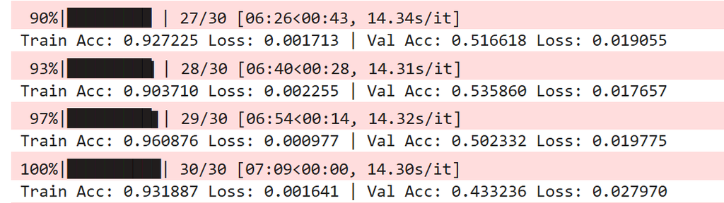

可以发现，三层的CNN训练集的准确率远远高于验证集的准确率，出现了过拟合的现象，原因可能是CNN网络的层数过少，导致输入到全连接层的参数量很大，进而导致全连接网络过于复杂，导致出现了过拟合。

### 5.2 进行Data Normalization

我们尝试在训练之前先对数据做标准化，再进行训练

```python
# 对数据集做标准化
train_transform = transforms.Compose([
    transforms.ToPILImage(),
    # transforms.RandomHorizontalFlip(),      # 随机水平翻转
    # transforms.RandomRotation(15),          # 随机旋转最大15度
    transforms.ToTensor(),                  # 转换为Tensor
    transforms.Normalize(mean=[0.5, 0.5, 0.5], std=[0.5, 0.5, 0.5])  # 标准化
])
# 测试集和验证集不需要数据增强
test_valid_transform = transforms.Compose([
    transforms.ToPILImage(),
    transforms.ToTensor(),              # 转换为Tensor
    transforms.Normalize(mean=[0.5, 0.5, 0.5], std=[0.5, 0.5, 0.5])  # 标准化
])
# 使用重写的 ImageDataSet 导入处理好的数据
train_set = ImageDataSet(train_x,train_y,train_transform)
val_set = ImageDataSet(val_x,val_y,test_valid_transform)
test_set = ImageDataSet(test_x,None,test_valid_transform)

#加载数据
batch_size = 128
train_loader = DataLoader(train_set,batch_size=batch_size,shuffle=True)
val_loader = DataLoader(val_set,batch_size=batch_size,shuffle=False)
test_loader = DataLoader(test_set,batch_size=batch_size,shuffle=False)

class Image_Classifier(nn.Module):
    def __init__(self):
        super(Image_Classifier,self).__init__() #初始化Image_Classifier的父类nn.Module
        self.cnn = nn.Sequential( #创建一个顺序结构的网络

            # Conv2d(输入通道数，输出通道数（卷积核个数），卷积核大小，步长，填充)
            # 用于卷积层进行卷积操作

            nn.Conv2d(3,64,3,1,1), # 输入通道数 3 (RGB)，输出通道数 64（卷积核的个数），卷积核大小 3x3，步长 1，填充 1
            nn.BatchNorm2d(64), #进行归一化操作
            nn.ReLU(),#使用ReLU作为激活函数
            nn.MaxPool2d(2,2,0), #最大池化，池化大小为2x2，步长为2，填充为0
            # [64,128,128] -> [64,128,128] -> [64,64,64]

            nn.Conv2d(64,128,3,1,1),
            nn.BatchNorm2d(128), #对做完卷积后的256个feature map做归一化
            nn.ReLU(),
            nn.MaxPool2d(2,2,0), # [128, 32, 32]


            nn.Conv2d(128, 256, 3, 1, 1),
            nn.BatchNorm2d(256),
            nn.ReLU(),
            nn.MaxPool2d(2, 2, 0), # [256, 16, 16]

            nn.Conv2d(256, 512, 3, 1, 1),
            nn.BatchNorm2d(512),
            nn.ReLU(),
            nn.MaxPool2d(2, 2, 0), # [512, 8, 8]
            #nn.Dropout2d(p=0.3), #Dropout 以概率p=0.3随机丢弃部分神经元

            nn.Conv2d(512, 512, 3, 1, 1),
            nn.BatchNorm2d(512),
            nn.ReLU(),
            nn.MaxPool2d(2, 2, 0),# [512, 4, 4]
            #nn.Dropout2d(p=0.3),
        )
        self.full_connect = nn.Sequential(
            nn.Linear(512*4*4 ,1024), #将 512x4x4 的特征图展平为 1024 个特征
            nn.ReLU(),
            nn.Linear(1024,512),
            nn.ReLU(),
            nn.Linear(512,11) #最终将1024个特征减小至11个特征
        )
    def forward(self,x):
        output = self.cnn(x)
        output = output.view(output.size()[0],-1) #展平特征图
        return self.full_connect(output)


model = Image_Classifier().cuda() #将Image_Classifier实例化，并加载到GPU上进行运算
loss = nn.CrossEntropyLoss() #分类模型，使用交叉熵损失
#创建一个Adam优化器，并将学习率设置为0.001，设置正则化参数为0.0001
optimizer = torch.optim.Adam(model.parameters(),lr=0.001,weight_decay=0.001)
epoch_num = 30 #小批量梯度下降

import time
from tqdm import trange
#开始训练！
for epoch in trange(epoch_num): #小批量梯度下降
    start_time = time.time()
    train_acc = 0.0
    train_loss = 0.0
    val_loss = 0.0
    val_acc = 0.0

    model.train() #切换至训练模式
    for i,(images,labels) in enumerate(train_loader):
        optimizer.zero_grad() #清空梯度
        train_pred = model(images.cuda()) #使用我们创建的模型进行训练
        batch_loss = loss(train_pred,labels.cuda()) #计算损失
        batch_loss.backward() #利用反向传播计算每一层参数的梯度
        optimizer.step() #更新梯度
        #与标签值对比，统计预测正确的个数
        train_acc += np.sum(np.argmax(train_pred.cpu().data.numpy(),axis=1)==labels.numpy())
        train_loss += batch_loss.item() #累计每个batch的损失

    train_acc = train_acc/train_set.__len__()
    train_loss = train_loss/train_set.__len__()

    model.eval() #切换至验证模式
    with torch.no_grad(): #在验证是不需要计算梯度
        for i ,(images,labels) in enumerate(val_loader):
            val_pred = model(images.cuda()) #使用我们创建的模型进行训练
            batch_loss = loss(val_pred,labels.cuda()) #计算损失

            #与标签值对比，统计预测正确的个数
            val_acc += np.sum(np.argmax(val_pred.cpu().data.numpy(),axis=1)==labels.numpy())
            val_loss += batch_loss.item() #累计每个batch的损失

        val_acc = val_acc/val_set.__len__()
        val_loss = val_loss/val_set.__len__()

        print('Train Acc: %3.6f Loss: %3.6f | Val Acc: %3.6f Loss: %3.6f' % (train_acc, train_loss, val_acc, val_loss))
```

```
Train Acc: 0.225725 Loss: 0.018327 | Val Acc: 0.209038 Loss: 0.018158
```

```
Train Acc: 0.311068 Loss: 0.015398 | Val Acc: 0.317201 Loss: 0.014838
```

```
Train Acc: 0.365092 Loss: 0.014276 | Val Acc: 0.365015 Loss: 0.014365
```

```
Train Acc: 0.413846 Loss: 0.013325 | Val Acc: 0.344898 Loss: 0.015467
```

```
Train Acc: 0.446990 Loss: 0.012513 | Val Acc: 0.306706 Loss: 0.015968
```

```
Train Acc: 0.473140 Loss: 0.012052 | Val Acc: 0.385131 Loss: 0.015536
```

```
Train Acc: 0.511960 Loss: 0.011172 | Val Acc: 0.421574 Loss: 0.013197
```

```
Train Acc: 0.525238 Loss: 0.010720 | Val Acc: 0.414577 Loss: 0.013301
```

```
Train Acc: 0.578350 Loss: 0.009587 | Val Acc: 0.535860 Loss: 0.010574
```

```
Train Acc: 0.590918 Loss: 0.009314 | Val Acc: 0.458892 Loss: 0.012853
```

```
Train Acc: 0.609365 Loss: 0.008909 | Val Acc: 0.418076 Loss: 0.015110
```

```
Train Acc: 0.620312 Loss: 0.008619 | Val Acc: 0.399125 Loss: 0.014833
```

```
Train Acc: 0.644435 Loss: 0.008121 | Val Acc: 0.488338 Loss: 0.012973
```

```
Train Acc: 0.663491 Loss: 0.007643 | Val Acc: 0.610787 Loss: 0.009116
```

```
Train Acc: 0.689134 Loss: 0.006967 | Val Acc: 0.560641 Loss: 0.011484
```

```
Train Acc: 0.716298 Loss: 0.006596 | Val Acc: 0.495918 Loss: 0.012499
```

```
Train Acc: 0.716501 Loss: 0.006518 | Val Acc: 0.571720 Loss: 0.010799
```

```
Train Acc: 0.748226 Loss: 0.005778 | Val Acc: 0.600292 Loss: 0.009891
```

```
Train Acc: 0.752281 Loss: 0.005752 | Val Acc: 0.466472 Loss: 0.015703
```

```
Train Acc: 0.762518 Loss: 0.005338 | Val Acc: 0.520408 Loss: 0.012955
```

```
Train Acc: 0.788972 Loss: 0.004868 | Val Acc: 0.633528 Loss: 0.008771
```

```
Train Acc: 0.805696 Loss: 0.004390 | Val Acc: 0.548688 Loss: 0.012426
```

```
Train Acc: 0.827894 Loss: 0.003949 | Val Acc: 0.581341 Loss: 0.011393
```

```
Train Acc: 0.856477 Loss: 0.003416 | Val Acc: 0.537318 Loss: 0.014852
```

```
Train Acc: 0.838942 Loss: 0.003642 | Val Acc: 0.649854 Loss: 0.010060
```

```
Train Acc: 0.885567 Loss: 0.002659 | Val Acc: 0.644898 Loss: 0.010560
```

```
Train Acc: 0.912427 Loss: 0.002069 | Val Acc: 0.599708 Loss: 0.012400
```

```
Train Acc: 0.890330 Loss: 0.002561 | Val Acc: 0.485714 Loss: 0.019955
```

```
Train Acc: 0.914048 Loss: 0.001935 | Val Acc: 0.626531 Loss: 0.012033
```

```
Train Acc: 0.942023 Loss: 0.001392 | Val Acc: 0.505831 Loss: 0.022262
```

#### 5.2.1 训练结果

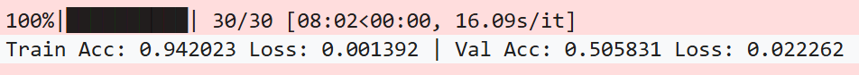

可以发现由于我们只做了数据标准化，并没有做数据增强，导致训练集的准确度相比之前有所增加，但验证集的准确度并没有增加。

### 5.3 进行 Data Augmentation

```python
# 对训练数据做数据增强
train_transform = transforms.Compose([
    transforms.ToPILImage(),
    transforms.RandomHorizontalFlip(),      # 随机水平翻转
    transforms.RandomRotation(30),          # 随机旋转最大30度
    transforms.ToTensor(),                  # 转换为Tensor
    transforms.Normalize(mean=[0.5, 0.5, 0.5], std=[0.5, 0.5, 0.5])  # 标准化
])
# 测试集和验证集不需要数据增强
test_valid_transform = transforms.Compose([
    transforms.ToPILImage(),
    transforms.ToTensor(),              # 转换为Tensor
    transforms.Normalize(mean=[0.5, 0.5, 0.5], std=[0.5, 0.5, 0.5])  # 标准化
])
# 使用重写的 ImageDataSet 导入处理好的数据
train_set = ImageDataSet(train_x,train_y,train_transform)
val_set = ImageDataSet(val_x,val_y,test_valid_transform)
test_set = ImageDataSet(test_x,None,test_valid_transform)

#加载数据
batch_size = 128
train_loader = DataLoader(train_set,batch_size=batch_size,shuffle=True)
val_loader = DataLoader(val_set,batch_size=batch_size,shuffle=False)
test_loader = DataLoader(test_set,batch_size=batch_size,shuffle=False)

class Image_Classifier(nn.Module):
    def __init__(self):
        super(Image_Classifier,self).__init__() #初始化Image_Classifier的父类nn.Module
        self.cnn = nn.Sequential( #创建一个顺序结构的网络

            # Conv2d(输入通道数，输出通道数（卷积核个数），卷积核大小，步长，填充)
            # 用于卷积层进行卷积操作

            nn.Conv2d(3,64,3,1,1), # 输入通道数 3 (RGB)，输出通道数 64（卷积核的个数），卷积核大小 3x3，步长 1，填充 1
            nn.BatchNorm2d(64), #进行归一化操作
            nn.ReLU(),#使用ReLU作为激活函数
            nn.MaxPool2d(2,2,0), #最大池化，池化大小为2x2，步长为2，填充为0
            # [64,128,128] -> [64,128,128] -> [64,64,64]

            nn.Conv2d(64,128,3,1,1),
            nn.BatchNorm2d(128), #对做完卷积后的256个feature map做归一化
            nn.ReLU(),
            nn.MaxPool2d(2,2,0), # [128, 32, 32]


            nn.Conv2d(128, 256, 3, 1, 1),
            nn.BatchNorm2d(256),
            nn.ReLU(),
            nn.MaxPool2d(2, 2, 0), # [256, 16, 16]

            nn.Conv2d(256, 512, 3, 1, 1),
            nn.BatchNorm2d(512),
            nn.ReLU(),
            nn.MaxPool2d(2, 2, 0), # [512, 8, 8]
            #nn.Dropout2d(p=0.3), #Dropout 以概率p=0.3随机丢弃部分神经元

            nn.Conv2d(512, 512, 3, 1, 1),
            nn.BatchNorm2d(512),
            nn.ReLU(),
            nn.MaxPool2d(2, 2, 0),# [512, 4, 4]
            #nn.Dropout2d(p=0.3),
        )
        self.full_connect = nn.Sequential(
            nn.Linear(512*4*4 ,1024), #将 512x4x4 的特征图展平为 1024 个特征
            nn.ReLU(),
            nn.Linear(1024,512),
            nn.ReLU(),
            nn.Linear(512,11) #最终将1024个特征减小至11个特征
        )
    def forward(self,x):
        output = self.cnn(x)
        output = output.view(output.size()[0],-1) #展平特征图
        return self.full_connect(output)


model = Image_Classifier().cuda() #将Image_Classifier实例化，并加载到GPU上进行运算
loss = nn.CrossEntropyLoss() #分类模型，使用交叉熵损失
#创建一个Adam优化器，并将学习率设置为0.001，设置正则化参数为0.0001
optimizer = torch.optim.Adam(model.parameters(),lr=0.001,weight_decay=0.001)
epoch_num = 60 #小批量梯度下降

# 用来保存训练过程中的准确率和损失值
train_accuracies = []
train_losses = []
val_accuracies = []
val_losses = []

import time
from tqdm import trange
#开始训练！
for epoch in trange(epoch_num): #小批量梯度下降
    start_time = time.time()
    train_acc = 0.0
    train_loss = 0.0
    val_loss = 0.0
    val_acc = 0.0

    model.train() #切换至训练模式
    for i,(images,labels) in enumerate(train_loader):
        optimizer.zero_grad() #清空梯度
        train_pred = model(images.cuda()) #使用我们创建的模型进行训练
        batch_loss = loss(train_pred,labels.cuda()) #计算损失
        batch_loss.backward() #利用反向传播计算每一层参数的梯度
        optimizer.step() #更新梯度
        #与标签值对比，统计预测正确的个数
        train_acc += np.sum(np.argmax(train_pred.cpu().data.numpy(),axis=1)==labels.numpy())
        train_loss += batch_loss.item() #累计每个batch的损失

    train_acc = train_acc/train_set.__len__()
    train_loss = train_loss/train_set.__len__()

    model.eval() #切换至验证模式
    with torch.no_grad(): #在验证是不需要计算梯度
        for i ,(images,labels) in enumerate(val_loader):
            val_pred = model(images.cuda()) #使用我们创建的模型进行训练
            batch_loss = loss(val_pred,labels.cuda()) #计算损失

            #与标签值对比，统计预测正确的个数
            val_acc += np.sum(np.argmax(val_pred.cpu().data.numpy(),axis=1)==labels.numpy())
            val_loss += batch_loss.item() #累计每个batch的损失

        val_acc = val_acc/val_set.__len__()
        val_loss = val_loss/val_set.__len__()

        print('Train Acc: %3.6f Loss: %3.6f | Val Acc: %3.6f Loss: %3.6f' % (train_acc, train_loss, val_acc, val_loss))


    # 记录每个 epoch 的训练和验证的准确率与损失
        val_accuracies.append(val_acc)
        val_losses.append(val_loss)

    train_accuracies.append(train_acc)
    train_losses.append(train_loss)
```

```
Train Acc: 0.211940 Loss: 0.018828 | Val Acc: 0.178426 Loss: 0.018566
```

```
Train Acc: 0.309447 Loss: 0.015657 | Val Acc: 0.300583 Loss: 0.015375
```

```
Train Acc: 0.355869 Loss: 0.014392 | Val Acc: 0.332945 Loss: 0.015182
```

```
Train Acc: 0.404217 Loss: 0.013377 | Val Acc: 0.305539 Loss: 0.015122
```

```
Train Acc: 0.443848 Loss: 0.012564 | Val Acc: 0.292128 Loss: 0.016035
```

```
Train Acc: 0.476890 Loss: 0.011897 | Val Acc: 0.429446 Loss: 0.013447
```

```
Train Acc: 0.507095 Loss: 0.011373 | Val Acc: 0.423032 Loss: 0.013346
```

```
Train Acc: 0.519866 Loss: 0.010986 | Val Acc: 0.368222 Loss: 0.015675
```

```
Train Acc: 0.535678 Loss: 0.010551 | Val Acc: 0.481924 Loss: 0.012382
```

```
Train Acc: 0.557470 Loss: 0.010069 | Val Acc: 0.484548 Loss: 0.012084
```

```
Train Acc: 0.583012 Loss: 0.009490 | Val Acc: 0.418367 Loss: 0.014575
```

```
Train Acc: 0.584330 Loss: 0.009570 | Val Acc: 0.528571 Loss: 0.011062
```

```
Train Acc: 0.607845 Loss: 0.009067 | Val Acc: 0.514869 Loss: 0.012259
```

```
Train Acc: 0.623252 Loss: 0.008761 | Val Acc: 0.555394 Loss: 0.011241
```

```
Train Acc: 0.626900 Loss: 0.008631 | Val Acc: 0.448105 Loss: 0.012519
```

```
Train Acc: 0.651835 Loss: 0.007953 | Val Acc: 0.442566 Loss: 0.014793
```

```
Train Acc: 0.651531 Loss: 0.008077 | Val Acc: 0.526822 Loss: 0.011619
```

```
Train Acc: 0.660957 Loss: 0.007764 | Val Acc: 0.575219 Loss: 0.010440
```

```
Train Acc: 0.675248 Loss: 0.007620 | Val Acc: 0.606414 Loss: 0.009496
```

```
Train Acc: 0.675147 Loss: 0.007423 | Val Acc: 0.439942 Loss: 0.015760
```

```
Train Acc: 0.677073 Loss: 0.007431 | Val Acc: 0.500292 Loss: 0.013678
```

```
Train Acc: 0.694810 Loss: 0.007128 | Val Acc: 0.658601 Loss: 0.008001
```

```
Train Acc: 0.708494 Loss: 0.006583 | Val Acc: 0.612536 Loss: 0.009450
```

```
Train Acc: 0.721366 Loss: 0.006511 | Val Acc: 0.616618 Loss: 0.009379
```

```
Train Acc: 0.724711 Loss: 0.006265 | Val Acc: 0.660058 Loss: 0.008128
```

```
Train Acc: 0.730995 Loss: 0.006221 | Val Acc: 0.618659 Loss: 0.009508
```

```
Train Acc: 0.741131 Loss: 0.005946 | Val Acc: 0.670262 Loss: 0.008371
```

```
Train Acc: 0.750760 Loss: 0.005773 | Val Acc: 0.580175 Loss: 0.010555
```

```
Train Acc: 0.760186 Loss: 0.005504 | Val Acc: 0.631778 Loss: 0.008973
```

```
Train Acc: 0.769207 Loss: 0.005404 | Val Acc: 0.653644 Loss: 0.008421
```

```
Train Acc: 0.749949 Loss: 0.005758 | Val Acc: 0.658892 Loss: 0.008448
```

```
Train Acc: 0.770322 Loss: 0.005313 | Val Acc: 0.631778 Loss: 0.009759
```

```
Train Acc: 0.795054 Loss: 0.004924 | Val Acc: 0.667055 Loss: 0.008566
```

```
Train Acc: 0.792114 Loss: 0.004904 | Val Acc: 0.670262 Loss: 0.008539
```

```
Train Acc: 0.795561 Loss: 0.004788 | Val Acc: 0.658601 Loss: 0.008523
```

```
Train Acc: 0.792114 Loss: 0.004693 | Val Acc: 0.663557 Loss: 0.008667
```

```
Train Acc: 0.808129 Loss: 0.004447 | Val Acc: 0.648980 Loss: 0.009603
```

```
Train Acc: 0.801743 Loss: 0.004619 | Val Acc: 0.675510 Loss: 0.008074
```

```
Train Acc: 0.802250 Loss: 0.004621 | Val Acc: 0.695627 Loss: 0.007960
```

```
Train Acc: 0.811879 Loss: 0.004444 | Val Acc: 0.691545 Loss: 0.008266
```

```
Train Acc: 0.812690 Loss: 0.004315 | Val Acc: 0.686297 Loss: 0.008489
```

```
Train Acc: 0.831948 Loss: 0.003837 | Val Acc: 0.701749 Loss: 0.007565
```

```
Train Acc: 0.849382 Loss: 0.003570 | Val Acc: 0.693586 Loss: 0.007984
```

```
Train Acc: 0.840158 Loss: 0.003806 | Val Acc: 0.630029 Loss: 0.010921
```

```
Train Acc: 0.808737 Loss: 0.004393 | Val Acc: 0.750729 Loss: 0.006491
```

```
Train Acc: 0.854247 Loss: 0.003514 | Val Acc: 0.739650 Loss: 0.006899
```

```
Train Acc: 0.844618 Loss: 0.003621 | Val Acc: 0.690087 Loss: 0.008585
```

```
Train Acc: 0.848165 Loss: 0.003589 | Val Acc: 0.682507 Loss: 0.008095
```

```
Train Acc: 0.854551 Loss: 0.003471 | Val Acc: 0.708163 Loss: 0.007954
```

```
Train Acc: 0.839955 Loss: 0.003683 | Val Acc: 0.713411 Loss: 0.007764
```

```
Train Acc: 0.851916 Loss: 0.003559 | Val Acc: 0.660350 Loss: 0.009780
```

```
Train Acc: 0.866815 Loss: 0.003131 | Val Acc: 0.740233 Loss: 0.007016
```

```
Train Acc: 0.862761 Loss: 0.003218 | Val Acc: 0.717493 Loss: 0.007542
```

```
Train Acc: 0.882424 Loss: 0.002727 | Val Acc: 0.760641 Loss: 0.006539
```

```
Train Acc: 0.883742 Loss: 0.002713 | Val Acc: 0.711370 Loss: 0.007319
```

```
Train Acc: 0.873809 Loss: 0.002847 | Val Acc: 0.714869 Loss: 0.008096
```

```
Train Acc: 0.884249 Loss: 0.002788 | Val Acc: 0.703207 Loss: 0.008974
```

```
Train Acc: 0.870363 Loss: 0.002898 | Val Acc: 0.738192 Loss: 0.007329
```

```
Train Acc: 0.889824 Loss: 0.002662 | Val Acc: 0.720991 Loss: 0.007914
```

```
Train Acc: 0.889520 Loss: 0.002683 | Val Acc: 0.672303 Loss: 0.009795
```

#### 5.3.1 训练结果

[figure not shown]

可以发现进行数据增强之后，验证集的准确率大幅增加，这表明数据增强可以提升模型的泛化能力，防止模型过拟合。

#### 5.3.2 绘制准确率和损失曲线

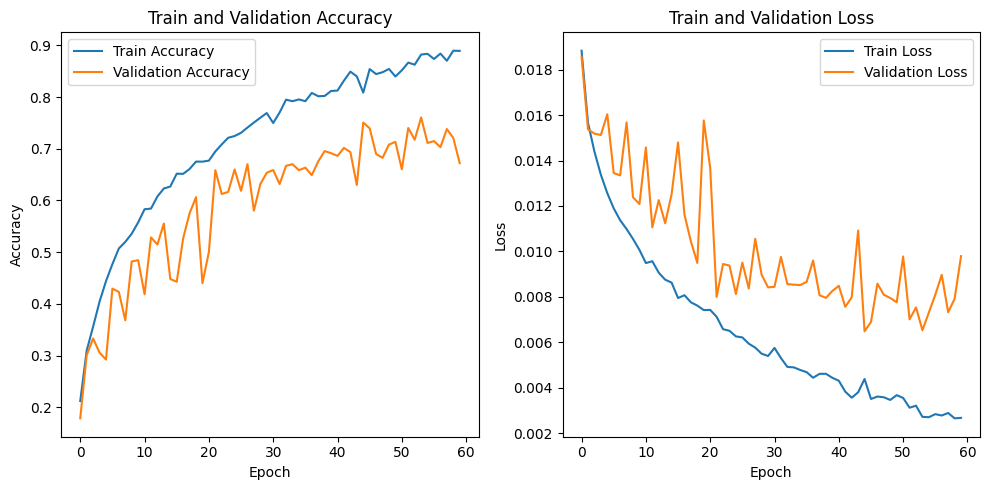

```python
# 绘制训练和验证的准确率曲线
plt.figure(figsize=(10, 5))
plt.subplot(1, 2, 1)
plt.plot(range(epoch_num), train_accuracies, label='Train Accuracy')
plt.plot(range(epoch_num), val_accuracies, label='Validation Accuracy')
plt.title('Train and Validation Accuracy')
plt.xlabel('Epoch')
plt.ylabel('Accuracy')
plt.legend()

# 绘制训练和验证的损失曲线
plt.subplot(1, 2, 2)
plt.plot(range(epoch_num), train_losses, label='Train Loss')
plt.plot(range(epoch_num), val_losses, label='Validation Loss')
plt.title('Train and Validation Loss')
plt.xlabel('Epoch')
plt.ylabel('Loss')
plt.legend()

plt.tight_layout()
plt.show()
```

#### 5.3.3 将预测结果写入文件

```python
import pandas as pd
import numpy as np

# 存储预测结果
ids = []
categories = []

# 切换到评估模式
model.eval()

# 在测试时不需要计算梯度
with torch.no_grad():
    for i, images in enumerate(test_loader):  # 只需要 images，不需要 labels
        # 获取预测结果
        test_pred = model(images.cuda())  # 使用模型进行预测
        predicted_categories = np.argmax(test_pred.cpu().data.numpy(), axis=1)
        start_idx = i * batch_size
        for j, category in enumerate(predicted_categories):
            ids.append(start_idx + j)  # 使用行号作为 ID
            categories.append(category)  # 预测类别

# 创建一个 DataFrame
df = pd.DataFrame({
    'Id': ids,
    'Category': categories
})

# 保存为 CSV 文件
df.to_csv('test_predictions.csv', index=False)

print("Predictions saved to 'test_predictions.csv'")
```

```
Predictions saved to 'test_predictions.csv'
```